# California Wildfire Analysis

Ethan Anghelache

How much do human factors (population, WUI housing growth, roads) explain where wildfires start in California, and can they predict which counties face rising ignition risk?

#### Question: How much do human factors (population, WUI housing growth, roads) explain where wildfires start in California, and can they predict which counties face rising ignition risk?

#### Methods: I use SQL to pull California wildfire ignitions and compare human-caused, lightning-caused, and unknown-cause fires over time. Using a spatial join, I calculate ignition density for each county from 2000–2020, compare it to WUI housing growth over the same period, and test their relationship with a Spearman correlation. I then classify counties into four risk groups and train linear regression and random forest models on 2000–2015 county-year data to predict ignition density, testing them on 2016–2020.

#### Data: Wildfire ignitions come from the Fire Program Analysis Fire-Occurrence Database (FPA FOD, Short 2026, 7th Edition). Housing, vegetation, and WUI classifications come from the SILVIS Lab 1990–2020 Wildland-Urban Interface dataset (Radeloff et al. 2023, 4th Edition). County boundaries and major roads come from the U.S. Census TIGER/Line files via the `tigris` package.

```r
# Load Libraries
library(RSQLite)       # SQL for Fire Data
library(DBI)
library(sf)            # Spatial Data
library(dplyr)         # Data Wrangling
```

```r
library(tmap)          # Mapping Visualizations
library(tigris)        # Defining our Region
library(randomForest)  # Machine Learning
options(tigris_use_cache = TRUE)

# Fire database (SQL)
con <- dbConnect(SQLite(), "data/RDS_SQL/FPA_FOD_20260615.sqlite")

# California WUI blocks (filtered from the national file once, in the Console)
ca_wui <- st_read("data/OtherData/ca_wui.gpkg", quiet = TRUE)

# County boundaries, in the same projection as the WUI data
ca_counties <- counties(state = "CA", cb = TRUE, progress_bar = FALSE)
ca_counties <- st_transform(ca_counties, st_crs(ca_wui))

# Preview the fire data (SQL)
dbGetQuery(con, "
  SELECT FIRE_YEAR, DISCOVERY_DATE, NWCG_CAUSE_CLASSIFICATION,
         FIRE_SIZE, LATITUDE, LONGITUDE, FIPS_NAME
  FROM Fires
  WHERE STATE = 'CA'
  LIMIT 5
")
```

```
##   FIRE_YEAR DISCOVERY_DATE NWCG_CAUSE_CLASSIFICATION FIRE_SIZE LATITUDE
## 1      2005        2453404                     Human      0.10 40.03694
## 2      2004        2453138                   Natural      0.25 38.93306
## 3      2004        2453156                     Human      0.10 38.98417
## 4      2004        2453184                   Natural      0.10 38.55917
## 5      2004        2453184                   Natural      0.10 38.55917
##   LONGITUDE        FIPS_NAME
## 1 -121.0058    Plumas County
## 2 -120.4044    Placer County
## 3 -120.7356 El Dorado County
## 4 -119.9133    Alpine County
## 5 -119.9331    Alpine County
```

```r
# Preview the WUI data (key columns only, without the shape data)
head(st_drop_geometry(ca_wui)[, c("BLK20", "fips", "HU2000", "HU2020",
                                  "WUIFLAG2000", "WUIFLAG2020", "VEG2019PC")])
```

```
##             BLK20  fips HU2000 HU2020 WUIFLAG2000 WUIFLAG2020 VEG2019PC
## 1 060014001001000 06001      0      0           0           0 49.122807
## 2 060014001001001 06001      0      0           0           0 80.129032
## 3 060014001001002 06001      0      0           0           0 50.000000
## 4 060014001001003 06001      0      0           0           0 73.738113
## 5 060014001001004 06001      0      0           0           0  0.000000
## 6 060014001001005 06001      0      0           0           0  9.539474
```

```r
# Preview the counties
head(st_drop_geometry(ca_counties)[, c("NAME", "GEOID", "ALAND")])
```

```
##            NAME GEOID       ALAND
## 1   Santa Clara 06085  3343891498
## 2        Orange 06059  2054504217
## 30       Fresno 06019 15432656111
## 118      Madera 06039  5534050365
## 119    Imperial 06025 10814374223
## 186  Stanislaus 06099  3875010973
```

## 2. California fires over time

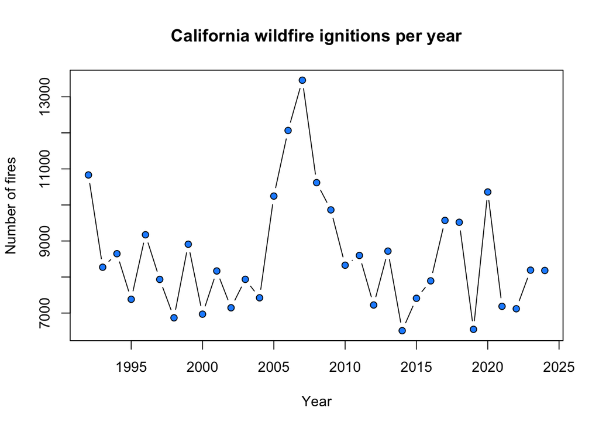

```r
fires_year <- dbGetQuery(con, "
  SELECT FIRE_YEAR, COUNT(*) AS n_fires
  FROM Fires
  WHERE STATE = 'CA'
  GROUP BY FIRE_YEAR
  ORDER BY FIRE_YEAR
")

plot(fires_year$FIRE_YEAR, fires_year$n_fires, type = "b",
     main = "California wildfire ignitions per year",
     xlab = "Year", ylab = "Number of fires",
     pch = 21, bg = "dodgerblue", col = "black")
```

**Takeaway (draft):** California averages roughly 7,000–9,000 wildfire ignitions per year, with no clear upward trend from 1992 to 2024. The biggest exception is 2005–2008, peaking at about 13,400 fires in 2007, though part of this spike may reflect changes in how agencies reported fires. Since fires have grown more destructive while the number of ignitions has stayed fairly flat, the more useful question we try to answer is not how many fires start, but where they start and who starts them.

## 3. Is it us? Human vs. lightning ignitions

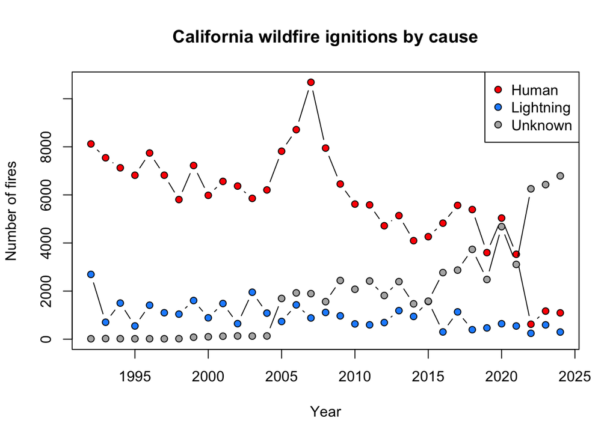

```r
cause_year <- dbGetQuery(con, "
  SELECT FIRE_YEAR, NWCG_CAUSE_CLASSIFICATION AS cause, COUNT(*) AS n_fires
  FROM Fires
  WHERE STATE = 'CA'
  GROUP BY FIRE_YEAR, cause
")

human   <- cause_year[cause_year$cause == "Human", ]
natural <- cause_year[cause_year$cause == "Natural", ]
unknown <- cause_year[cause_year$cause == "Missing data/not specified/undetermined", ]

plot(human$FIRE_YEAR, human$n_fires, type = "b",
     ylim = c(0, max(cause_year$n_fires)),
     main = "California wildfire ignitions by cause",
     xlab = "Year", ylab = "Number of fires",
     pch = 21, bg = "red", col = "black")
lines(natural$FIRE_YEAR, natural$n_fires, type = "b",
      pch = 21, bg = "dodgerblue", col = "black")
lines(unknown$FIRE_YEAR, unknown$n_fires, type = "b",
      pch = 21, bg = "gray70", col = "black")
legend("topright", legend = c("Human", "Lightning", "Unknown"),
       pt.bg = c("red", "dodgerblue", "gray70"), pch = 21)
```

```r
# Pull California fires from 2000–2020 (SQL)
ca_fires <- dbGetQuery(con, "
  SELECT FIRE_YEAR, NWCG_CAUSE_CLASSIFICATION AS cause,
         FIRE_SIZE, LATITUDE, LONGITUDE
  FROM Fires
  WHERE STATE = 'CA'
    AND FIRE_YEAR BETWEEN 2000 AND 2020
")

# Turn coordinates into map points, then match each fire to its county
fires_sf <- st_as_sf(ca_fires, coords = c("LONGITUDE", "LATITUDE"), crs = 4269)
fires_sf <- st_transform(fires_sf, st_crs(ca_counties))
fires_sf <- st_join(fires_sf, ca_counties[, c("GEOID", "NAME")])

nrow(fires_sf)
```

```
## [1] 184585
```

```r
county_fires <- fires_sf |>
  st_drop_geometry() |>
  filter(!is.na(GEOID)) |>              # drop any points that fell offshore
  group_by(GEOID) |>
  summarise(n_total   = n(),
            n_human   = sum(cause == "Human"),
            n_natural = sum(cause == "Natural"))

# Join counts to county shapes and calculate fires per 100 km² per year
n_years <- 21  # 2000–2020

ca_counties <- ca_counties |>
  left_join(county_fires, by = "GEOID") |>
  mutate(area_km2        = ALAND / 1e6,
         human_density   = round(n_human   / area_km2 * 100 / n_years, 3),
         natural_density = round(n_natural / area_km2 * 100 / n_years, 3),
         human_share     = round(n_human / n_total, 3))
```

```r
ca_counties |>
  st_drop_geometry() |>
  arrange(desc(human_density)) |>
  select(NAME, n_human, n_natural, human_density, natural_density, human_share) |>
  head(10)
```

```
##             NAME n_human n_natural human_density natural_density human_share
## 1  San Francisco     183         1         7.207           0.039       0.658
## 2     Santa Cruz    1327        11         5.481           0.045       0.777
## 3   Contra Costa    1980        11         5.078           0.028       0.647
## 4         Merced    5219        25         4.951           0.024       0.726
## 5      El Dorado    4558       485         4.907           0.522       0.821
## 6          Butte    4329       164         4.864           0.184       0.821
## 7         Placer    3526       304         4.606           0.397       0.727
## 8         Nevada    2250       217         4.319           0.417       0.785
## 9           Yuba    1470        25         4.276           0.073       0.774
## 10        Madera    4220       317         3.631           0.273       0.770
```

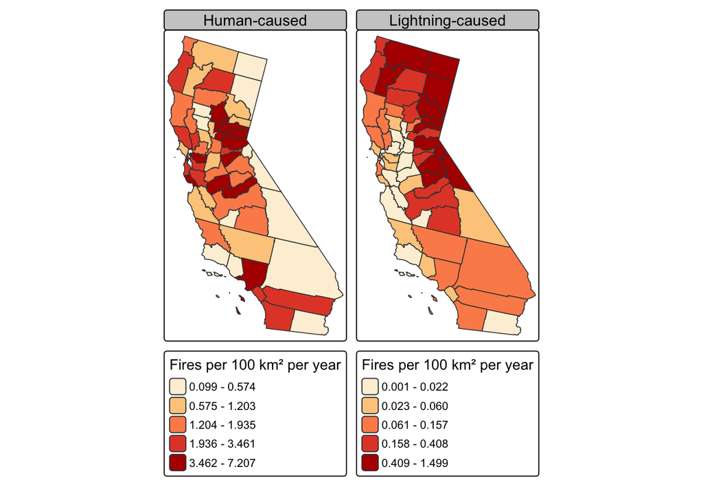

```r
tm_shape(ca_counties) +
  tm_polygons(fill = c("human_density", "natural_density"),
              fill.scale = tm_scale_intervals(style = "quantile",
                                              values = "brewer.or_rd"),
              fill.legend = tm_legend(title = "Fires per 100 km² per year")) +
  tm_layout(panel.labels = c("Human-caused", "Lightning-caused"))
```

## 5. WUI housing growth by county

```r
# Total WUI housing per county, 2000 vs. 2020
county_wui <- ca_wui |>
  st_drop_geometry() |>
  mutate(GEOID = substr(BLK20, 1, 5)) |>
  group_by(GEOID) |>
  summarise(wui_hu_2000 = sum(HU2000[WUIFLAG2000 > 0], na.rm = TRUE),
            wui_hu_2020 = sum(HU2020[WUIFLAG2020 > 0], na.rm = TRUE),
            veg_pct     = mean(VEG2019PC, na.rm = TRUE))

head(county_wui)
```

```
## # A tibble: 6 × 4
##   GEOID wui_hu_2000 wui_hu_2020 veg_pct
##   <chr>       <int>       <int>   <dbl>
## 1 06001      162781      198819    3.82
## 2 06003        1364        1407   76.6
## 3 06005       13649       17169   62.5
## 4 06007       55006       54419   32.7
## 5 06009       20823       25025   67.1
## 6 06011         427         451   16.3
```

```r
#Growth and join to counties
ca_counties <- ca_counties |>
  left_join(county_wui, by = "GEOID") |>
  mutate(wui_growth_pct = round((wui_hu_2020 - wui_hu_2000) / wui_hu_2000 * 100, 3),
         wui_new_units  = wui_hu_2020 - wui_hu_2000)

ca_counties |>
  st_drop_geometry() |>
  arrange(desc(wui_growth_pct)) |>
  select(NAME, wui_hu_2000, wui_hu_2020, wui_new_units, wui_growth_pct) |>
  head(10)
```

```
##           NAME wui_hu_2000 wui_hu_2020 wui_new_units wui_growth_pct
## 1  San Joaquin        1953        8743          6790        347.670
## 2   Stanislaus        1277        4100          2823        221.065
## 3   Sacramento       52441       95234         42793         81.602
## 4       Placer       69956      111933         41977         60.005
## 5       Merced        4320        6812          2492         57.685
## 6       Fresno       20203       29878          9675         47.889
## 7    Riverside      363652      528735        165083         45.396
## 8       Orange      174869      240980         66111         37.806
## 9    El Dorado       69091       91509         22418         32.447
## 10        Yolo        2734        3611           877         32.078
```

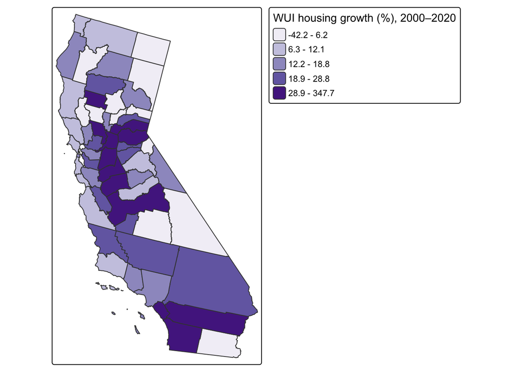

```r
#Map it
tm_shape(ca_counties) +
  tm_polygons(fill = "wui_growth_pct",
              fill.scale = tm_scale_intervals(style = "quantile",
                                              values = "brewer.purples"),
              fill.legend = tm_legend(title = "WUI housing growth (%), 2000–2020"))
```

**Takeaway (draft):** From 2000–2020, WUI housing grew most in the Central Valley, Sierra Nevada foothills, and Southern California. By percentage, San Joaquin (347.670%) and Stanislaus (221.065%) grew fastest, but from very small starting points; by number of new homes, Riverside added the most (165,083), followed by Orange, Sacramento, and Placer. Placer, Merced, and El Dorado rank in the top 10 for both WUI growth and human ignition density, suggesting these counties combine frequent human-caused fires with a rapidly growing number of homes at the wildland edge. Some northern and desert counties saw little growth or even declines in WUI housing.

## 6 Which counties face rising risk?

```r
#Build both measures and classify counties
ca_counties <- ca_counties |>
  mutate(total_density      = round(n_total / area_km2 * 100 / n_years, 3),
         wui_growth_density = round(wui_new_units / area_km2 * 100, 3),
         ign_rank           = round(percent_rank(total_density), 3),
         wui_rank           = round(percent_rank(wui_growth_density), 3),
         risk_group = case_when(
           ign_rank >= 0.5 & wui_rank >= 0.5 ~ "Rising risk",
           ign_rank >= 0.5                   ~ "Fire-prone, slow growth",
           wui_rank >= 0.5                   ~ "Growing, fewer fires",
           TRUE                              ~ "Lower concern"),
         risk_group = factor(risk_group,
                             levels = c("Rising risk", "Fire-prone, slow growth",
                                        "Growing, fewer fires", "Lower concern")))

table(ca_counties$risk_group)
```

```
##
##             Rising risk Fire-prone, slow growth    Growing, fewer fires
##                      22                       7                       7
##           Lower concern
##                      22
```

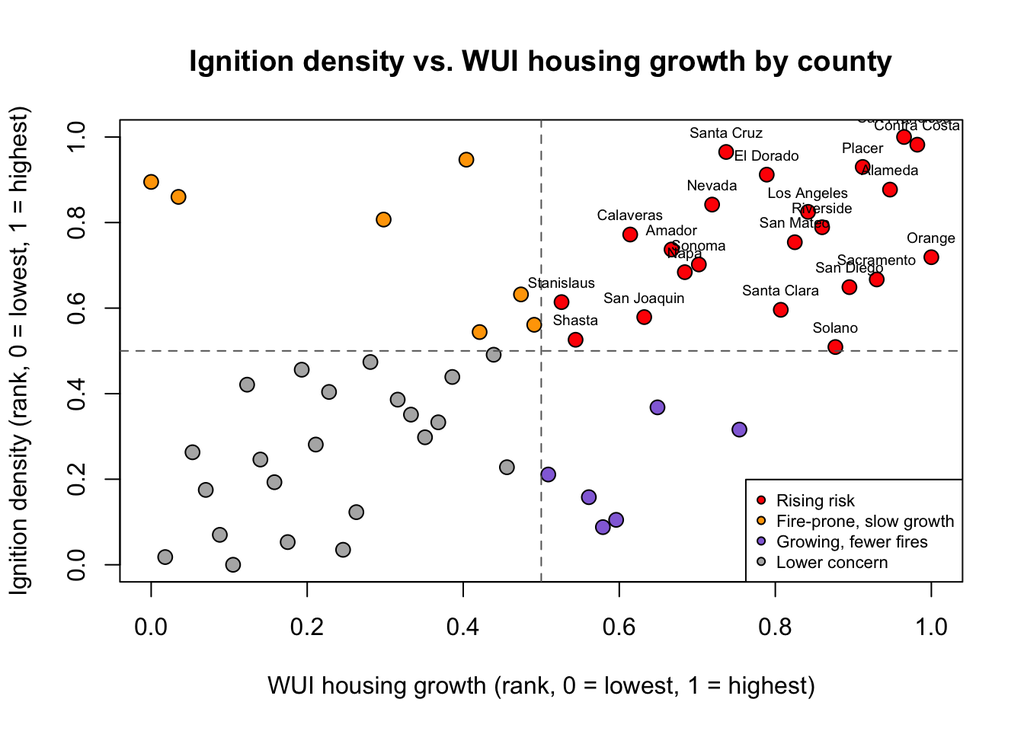

```r
#Quadrant plots
group_cols <- c("red", "orange", "mediumpurple", "gray70")
pt_cols <- group_cols[as.numeric(ca_counties$risk_group)]

plot(ca_counties$wui_rank, ca_counties$ign_rank,
     main = "Ignition density vs. WUI housing growth by county",
     xlab = "WUI housing growth (rank, 0 = lowest, 1 = highest)",
     ylab = "Ignition density (rank, 0 = lowest, 1 = highest)",
     pch = 21, bg = pt_cols, col = "black", cex = 1.3)
abline(h = 0.5, v = 0.5, lty = 2, col = "gray40")

rising <- ca_counties$risk_group == "Rising risk"
text(ca_counties$wui_rank[rising], ca_counties$ign_rank[rising],
     labels = ca_counties$NAME[rising], pos = 3, cex = 0.6)

legend("bottomright", legend = levels(ca_counties$risk_group),
       pt.bg = group_cols, pch = 21, cex = 0.7)
```

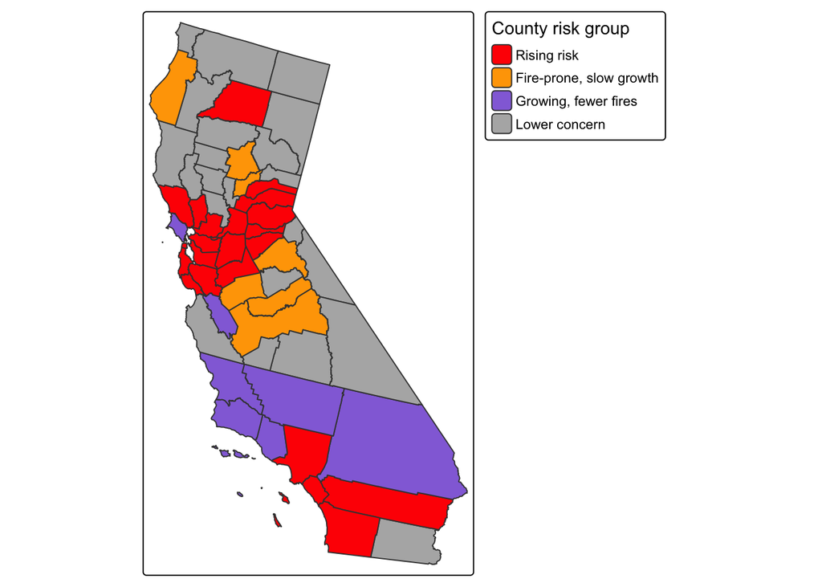

```r
#Map the 4 groups
tm_shape(ca_counties) +
  tm_polygons(fill = "risk_group",
              fill.scale = tm_scale_categorical(values = group_cols),
              fill.legend = tm_legend(title = "County risk group"))
```

```r
#The rising-risk counties
ca_counties |>
  st_drop_geometry() |>
  filter(risk_group == "Rising risk") |>
  mutate(combined_rank = round(ign_rank + wui_rank, 3)) |>
  arrange(desc(combined_rank)) |>
  select(NAME, total_density, wui_growth_density, ign_rank, wui_rank, combined_rank)
```

```
##             NAME total_density wui_growth_density ign_rank wui_rank
## 1  San Francisco        10.948           2151.951    1.000    0.965
## 2   Contra Costa         7.843           2324.850    0.982    0.982
## 3         Placer         6.338           1151.584    0.930    0.912
## 4        Alameda         5.814           1886.796    0.877    0.947
## 5         Orange         3.831           3217.857    0.719    1.000
## 6     Santa Cruz         7.055            433.373    0.965    0.737
## 7      El Dorado         5.974            506.817    0.912    0.789
## 8    Los Angeles         5.104            882.257    0.825    0.842
## 9      Riverside         4.566            884.155    0.789    0.860
## 10    Sacramento         3.611           1711.499    0.667    0.930
## 11     San Mateo         4.152            824.357    0.754    0.825
## 12        Nevada         5.504            388.779    0.842    0.719
## 13     San Diego         3.576            983.776    0.649    0.895
## 14        Amador         3.986            228.576    0.737    0.667
```

[output cut: 31 more lines]

```r
cor.test(ca_counties$total_density, ca_counties$wui_growth_density,
         method = "spearman")
```

```
##
##  Spearman's rank correlation rho
##
## data:  ca_counties$total_density and ca_counties$wui_growth_density
## S = 14518, p-value = 9.511e-06
## alternative hypothesis: true rho is not equal to 0
## sample estimates:
##      rho
## 0.553416
```

**Takeaway (draft):** WUI housing growth and ignition density are positively correlated across California counties (Spearman’s rho = 0.553, p < 0.001): counties adding more homes at the wildland edge also tend to have more fires per area. Most counties fall high or low on both measures, with 22 of 58 in the “Rising risk” group, 22 in “Lower concern,” and only 14 mixed. Rising-risk counties form two belts: one from the Bay Area through Sacramento into the Sierra Nevada foothills, and one across Southern California (Los Angeles, Orange, Riverside, and San Diego). Contra Costa, Placer, and Alameda rank highest on both measures combined; San Francisco technically ranks first, but its very small area inflates both densities, so it is not a realistic wildfire hotspot. This correlation shows the two patterns overlap, not that housing growth causes fires.

## 7 Predicting Ignition Density

```r
#Housing per county for each decade
county_housing <- ca_wui |>
  st_drop_geometry() |>
  mutate(GEOID = substr(BLK20, 1, 5)) |>
  group_by(GEOID) |>
  summarise(hu_2000  = sum(HU2000, na.rm = TRUE),
            hu_2010  = sum(HU2010, na.rm = TRUE),
            hu_2020  = sum(HU2020, na.rm = TRUE),
            wui_2000 = sum(HU2000[WUIFLAG2000 > 0], na.rm = TRUE),
            wui_2010 = sum(HU2010[WUIFLAG2010 > 0], na.rm = TRUE),
            wui_2020 = sum(HU2020[WUIFLAG2020 > 0], na.rm = TRUE))
```

```r
#Road length per county
ca_roads <- primary_secondary_roads(state = "CA", progress_bar = FALSE) |>
  st_transform(st_crs(ca_counties))
road_pieces <- st_intersection(ca_roads, ca_counties[, "GEOID"])
road_pieces$length_km <- as.numeric(st_length(road_pieces)) / 1000

county_roads <- road_pieces |>
  st_drop_geometry() |>
  group_by(GEOID) |>
  summarise(road_km = sum(length_km))
```

```r
#Building county-year dataset
# Fires per county per year
fires_cy <- fires_sf |>
  st_drop_geometry() |>
  filter(!is.na(GEOID)) |>
  count(GEOID, FIRE_YEAR, name = "n_fires")

# County features that don't change by year
county_static <- ca_counties |>
  st_drop_geometry() |>
  select(GEOID, NAME, area_km2, veg_pct) |>
  left_join(county_housing, by = "GEOID") |>
  left_join(county_roads, by = "GEOID") |>
  mutate(road_km = ifelse(is.na(road_km), 0, road_km))

# One row per county per year
panel <- expand.grid(GEOID = ca_counties$GEOID, year = 2000:2020,
                     stringsAsFactors = FALSE) |>
  left_join(fires_cy, by = c("GEOID", "year" = "FIRE_YEAR")) |>
  left_join(county_static, by = "GEOID") |>
  mutate(n_fires = ifelse(is.na(n_fires), 0, n_fires),
         # Fill in housing between census years
         hu  = ifelse(year <= 2010,
                      hu_2000 + (hu_2010 - hu_2000) * (year - 2000) / 10,
                      hu_2010 + (hu_2020 - hu_2010) * (year - 2010) / 10),
         wui = ifelse(year <= 2010,
                      wui_2000 + (wui_2010 - wui_2000) * (year - 2000) / 10,
                      wui_2010 + (wui_2020 - wui_2010) * (year - 2010) / 10),
         # Everything per 100 km² so big and small counties compare fairly
         ign_density     = n_fires / area_km2 * 100,
         housing_density = hu / area_km2 * 100,
         wui_density     = wui / area_km2 * 100,
         wui_share       = wui / hu,
         road_density    = road_km / area_km2 * 100) |>
  filter(NAME != "San Francisco")

nrow(panel)
```

```
## [1] 1197
```

```r
#Train on 2000-2015, test on 2016-2020
train <- panel[panel$year <= 2015, ]
test  <- panel[panel$year >  2015, ]

f <- ign_density ~ housing_density + wui_density + wui_share + road_density + veg_pct

# Baseline: linear regression
lm_fit <- lm(f, data = train)
summary(lm_fit)
```

```
##
## Call:
## lm(formula = f, data = train)
##
## Residuals:
##     Min      1Q  Median      3Q     Max
## -6.0655 -1.5398 -0.5676  1.1969 11.0372
##
## Coefficients:
##                   Estimate Std. Error t value Pr(>|t|)
## (Intercept)      2.539e+00  2.439e-01  10.407  < 2e-16 ***
## housing_density -1.825e-06  2.166e-05  -0.084   0.9329
## wui_density      4.228e-04  5.954e-05   7.101  2.5e-12 ***
## wui_share       -1.293e-01  4.608e-01  -0.281   0.7791
## road_density    -1.966e-02  9.570e-03  -2.055   0.0402 *
## veg_pct          7.543e-04  6.330e-03   0.119   0.9052
## ---
## Signif. codes:  0 '***' 0.001 '**' 0.01 '*' 0.05 '.' 0.1 ' ' 1
##
## Residual standard error: 2.297 on 906 degrees of freedom
## Multiple R-squared:  0.1561, Adjusted R-squared:  0.1514
## F-statistic: 33.51 on 5 and 906 DF,  p-value: < 2.2e-16
```

```r
# Machine learning: random forest
set.seed(124)
rf_fit <- randomForest(f, data = train, ntree = 500, importance = TRUE)
rf_fit
```

```
##
## Call:
##  randomForest(formula = f, data = train, ntree = 500, importance = TRUE)
##                Type of random forest: regression
##                      Number of trees: 500
## No. of variables tried at each split: 1
##
##           Mean of squared residuals: 1.521319
##                     % Var explained: 75.51
```

```r
#Compare models on the test years
rmse <- function(actual, pred) sqrt(mean((actual - pred)^2))
r2   <- function(actual, pred) 1 - sum((actual - pred)^2) / sum((actual - mean(actual))^2)

lm_pred <- predict(lm_fit, test)
rf_pred <- predict(rf_fit, test)

data.frame(Model = c("Linear regression", "Random forest"),
           RMSE  = round(c(rmse(test$ign_density, lm_pred),
                           rmse(test$ign_density, rf_pred)), 3),
           R2    = round(c(r2(test$ign_density, lm_pred),
                           r2(test$ign_density, rf_pred)), 3))
```

```
##               Model  RMSE    R2
## 1 Linear regression 2.082 0.255
## 2     Random forest 1.821 0.430
```

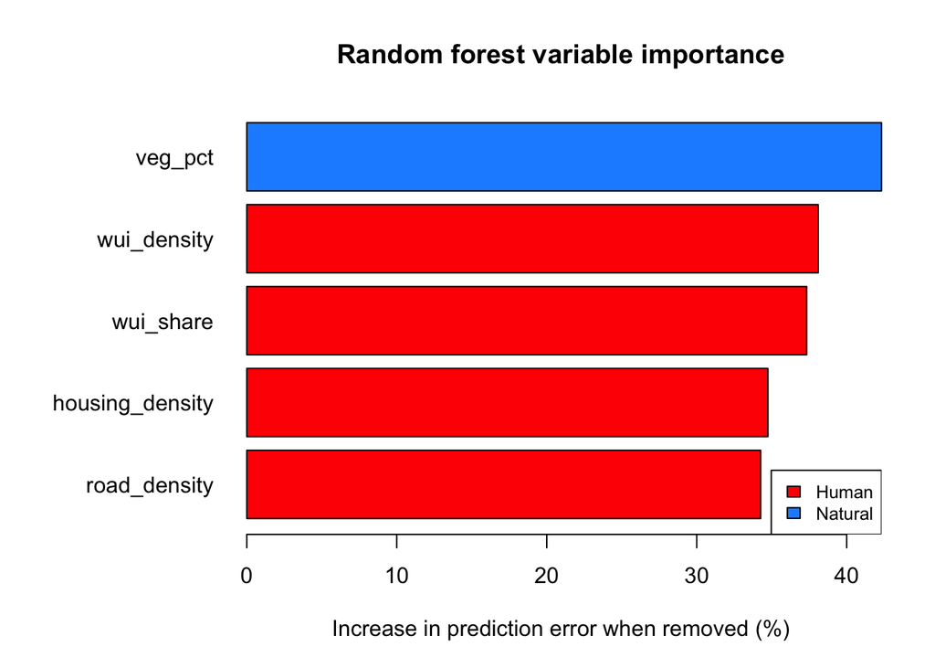

```r
#Which features matter? Human vs. natural
imp <- sort(importance(rf_fit)[, "%IncMSE"])
imp_cols <- ifelse(names(imp) == "veg_pct", "dodgerblue", "red")

par(mar = c(5, 9, 4, 2))
barplot(imp, horiz = TRUE, las = 1, col = imp_cols, border = "black",
        main = "Random forest variable importance",
        xlab = "Increase in prediction error when removed (%)")
legend("bottomright", legend = c("Human", "Natural"),
       fill = c("red", "dodgerblue"), cex = 0.8)
```

```r
par(mar = c(5, 4, 4, 2))
```

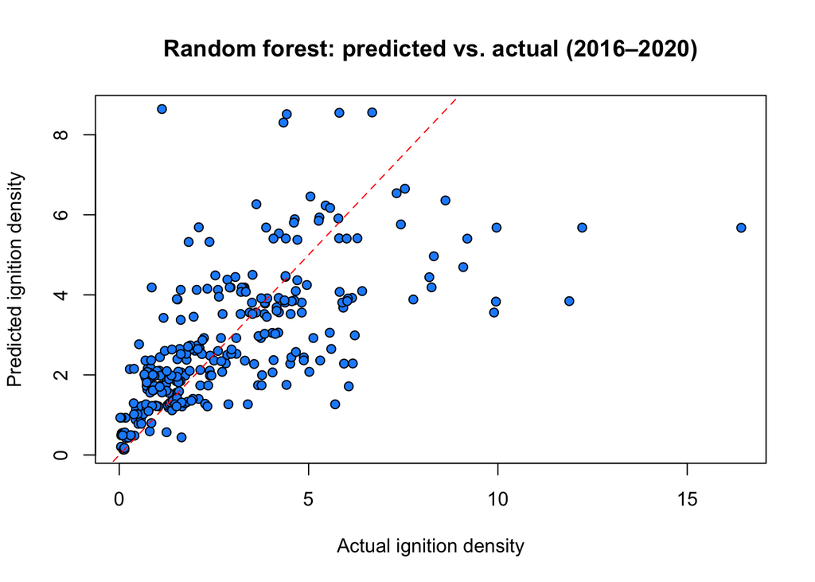

```r
#Predicted vs. Actual
plot(test$ign_density, rf_pred,
     main = "Random forest: predicted vs. actual (2016–2020)",
     xlab = "Actual ignition density", ylab = "Predicted ignition density",
     pch = 21, bg = "dodgerblue", col = "black")
abline(0, 1, lty = 2, col = "red")
```

**Takeaway (draft):** A random forest predicted 2016–2020 county ignition density better than linear regression (R² = 0.430 vs. 0.255; RMSE = 1.821 vs. 2.082 fires per 100 km²). Wildland vegetation was the single most important feature, but the four human features (WUI housing density, WUI share, housing density, and road density) ranked close behind and together carried most of the model’s predictive power. In the linear model, WUI housing density was the only strong predictor: each additional 1,000 WUI homes per 100 km² was associated with about 0.423 more ignitions per 100 km² per year. Together, these results suggest wildfires start where people and fuel meet, not from either alone. The model underpredicts extreme years, likely because it includes no weather or drought data, and its training accuracy (75.51%) is higher than its test accuracy because counties repeat across years, so the test R² is the more reliable measure.

## 8. Conclusion

**Is it us?** Mostly, yes, but not alone. Among fires with a known cause, humans start the large majority of California’s wildfires, and human-caused ignitions concentrate in the Bay Area, the Sierra Nevada foothills, and Southern California, while lightning fires cluster in remote northern and high-Sierra counties. Counties adding more homes at the wildland edge also tend to have more fires per area (Spearman’s rho = 0.553, p < 0.001). The random forest showed that vegetation and human development work together: fires start where people live next to fuel.

**Which counties face rising risk?** Twenty-two counties combine high ignition density with fast WUI housing growth. Contra Costa, Placer, and Alameda rank highest, followed by Orange, Santa Cruz, El Dorado, Los Angeles, Riverside, and Sacramento. These counties are where prevention efforts like defensible space, building codes, and ignition-reduction campaigns would likely have the most impact.

**Limitations.** The share of fires with an unknown cause rose from about 21% in 2015 to 45% in 2020 and above 78% after 2021, so cause-based results are limited to 2000–2020. WUI housing is only measured every 10 years, so yearly values were interpolated. The model includes no weather or drought data, which explains why it underpredicts extreme years. Finally, these results show strong associations, not proof that housing growth causes fires.

**Next steps.** Adding climate data (temperature, drought, wind) would likely improve year-to-year predictions, and using census tracts instead of counties would reveal where within each county risk is concentrated.

#### Ciations

```r
citation("RSQLite")
```

```
##
##   Müller K, Wickham H, James DA, Falcon S (2026). _RSQLite: SQLite
##   Interface for R_. doi:10.32614/CRAN.package.RSQLite
##   <https://doi.org/10.32614/CRAN.package.RSQLite>. R package version
##   3.53.3, <https://CRAN.R-project.org/package=RSQLite>.
##
## A BibTeX entry for LaTeX users is
##
##   @Manual{,
##     title = {RSQLite: SQLite Interface for R},
##     author = {Kirill Müller and Hadley Wickham and David A. James and Seth Falcon},
##     year = {2026},
##     note = {R package version 3.53.3},
##     url = {https://CRAN.R-project.org/package=RSQLite},
##     doi = {10.32614/CRAN.package.RSQLite},
##   }
```

```r
citation("DBI")
```

```
##
##   R Special Interest Group on Databases (R-SIG-DB), Wickham H, Müller K
##   (2026). _DBI: R Database Interface_. doi:10.32614/CRAN.package.DBI
##   <https://doi.org/10.32614/CRAN.package.DBI>. R package version 1.3.0,
##   <https://CRAN.R-project.org/package=DBI>.
##
## A BibTeX entry for LaTeX users is
##
##   @Manual{,
##     title = {DBI: R Database Interface},
##     author = {{R Special Interest Group on Databases (R-SIG-DB)} and Hadley Wickham and Kirill Müller},
##     year = {2026},
##     note = {R package version 1.3.0},
##     url = {https://CRAN.R-project.org/package=DBI},
##     doi = {10.32614/CRAN.package.DBI},
##   }
```

```r
citation("sf")
```

```
##
##   Pebesma, E., & Bivand, R. (2023). Spatial Data Science: With
##   Applications in R. Chapman and Hall/CRC.
##   https://doi.org/10.1201/9780429459016
##
##   Pebesma, E., 2018. Simple Features for R: Standardized Support for
##   Spatial Vector Data. The R Journal 10 (1), 439-446,
##   https://doi.org/10.32614/RJ-2018-009
##
## To see these entries in BibTeX format, use 'print(<citation>,
## bibtex=TRUE)', 'toBibtex(.)', or set
## 'options(citation.bibtex.max=999)'.
```

```r
citation("dplyr")
```

```
##
##   Wickham H, François R, Henry L, Müller K, Vaughan D (2026). _dplyr: A
##   Grammar of Data Manipulation_. doi:10.32614/CRAN.package.dplyr
##   <https://doi.org/10.32614/CRAN.package.dplyr>. R package version
##   1.2.1, <https://CRAN.R-project.org/package=dplyr>.
##
## A BibTeX entry for LaTeX users is
##
##   @Manual{,
##     title = {dplyr: A Grammar of Data Manipulation},
##     author = {Hadley Wickham and Romain François and Lionel Henry and Kirill Müller and Davis Vaughan},
##     year = {2026},
##     note = {R package version 1.2.1},
##     url = {https://CRAN.R-project.org/package=dplyr},
##     doi = {10.32614/CRAN.package.dplyr},
##   }
```

```r
citation("tmap")
```

```
##
##   Tennekes M (2018). "tmap: Thematic Maps in R." _Journal of
##   Statistical Software_, *84*(6), 1-39. doi:10.18637/jss.v084.i06
##   <https://doi.org/10.18637/jss.v084.i06>.
##
## A BibTeX entry for LaTeX users is
##
##   @Article{,
##     title = {{tmap}: Thematic Maps in {R}},
##     author = {Martijn Tennekes},
##     journal = {Journal of Statistical Software},
##     year = {2018},
##     volume = {84},
##     number = {6},
##     pages = {1--39},
##     doi = {10.18637/jss.v084.i06},
##   }
```

```r
citation("tigris")
```

```
##
##   Walker K (2026). _tigris: Load Census TIGER/Line Shapefiles_.
##   doi:10.32614/CRAN.package.tigris
##   <https://doi.org/10.32614/CRAN.package.tigris>. R package version
##   2.3.0, <https://CRAN.R-project.org/package=tigris>.
##
## A BibTeX entry for LaTeX users is
##
##   @Manual{,
##     title = {tigris: Load Census TIGER/Line Shapefiles},
##     author = {Kyle Walker},
##     year = {2026},
##     note = {R package version 2.3.0},
##     url = {https://CRAN.R-project.org/package=tigris},
##     doi = {10.32614/CRAN.package.tigris},
##   }
```

```r
citation("randomForest")
```

```
##
##   Liaw A, Wiener M (2002). "Classification and Regression by
##   randomForest." _R News_, *2*(3), 18-22.
##   <https://CRAN.R-project.org/doc/Rnews/>.
##
## A BibTeX entry for LaTeX users is
##
##   @Article{,
##     title = {Classification and Regression by randomForest},
##     author = {Andy Liaw and Matthew Wiener},
##     journal = {R News},
##     year = {2002},
##     volume = {2},
##     number = {3},
##     pages = {18-22},
##     url = {https://CRAN.R-project.org/doc/Rnews/},
##   }
```